# DataVis1

Sanghoo Yoon

## R 설치하기

- R 프로그램 : https://cran.r-project.org/
- R studio 프로그램 : https://www.rstudio.com/products/rstudio/download/

# 막대그림

기본적인 사용법은 아래의 사이트를 참고하여 제작하였습니다.

### 참고 : https://www.statmethods.net/graphs/bar.html

- 막대그림을 그리기 위해선 barplot이라는 함수에 그리는 **숫자의 벡터**를 입력하면 됩니다.

```r
counts <- table(mtcars$gear)
counts
```

```
##
##  3  4  5
## 15 12  5
```

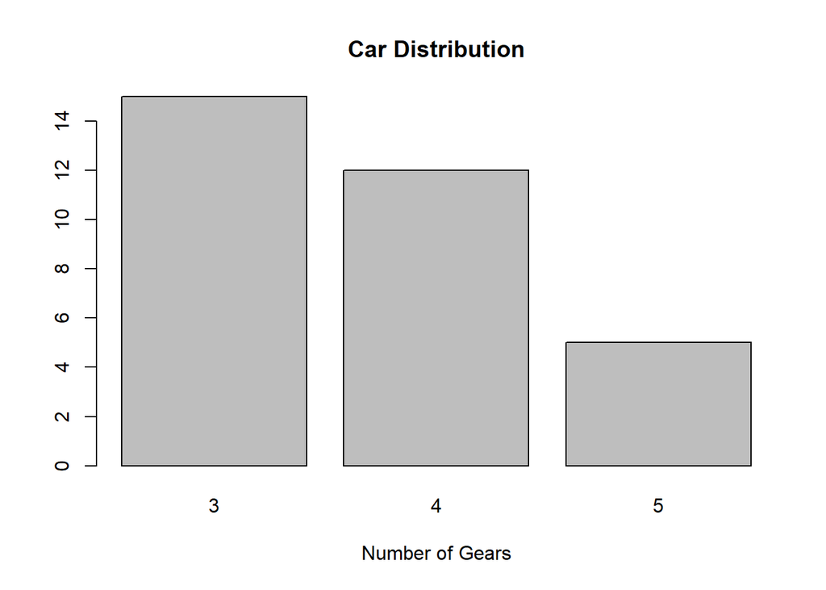

```r
barplot(counts, main="Car Distribution", xlab="Number of Gears")
```

여기서 main은 함수의 제목을 다는 parameter이고, xlab은 x축의 이름을 다는 parameter이다.

**문자를 입력**하기 위해선 `’ 또는 ""가 사용됨을 주의하자.

만약 막대그림을 **옆으로** 그리고 싶다면 horiz=TRUE을 추가하면 된다.

names.arg는 원하는 이름을 값에 입력해준다.

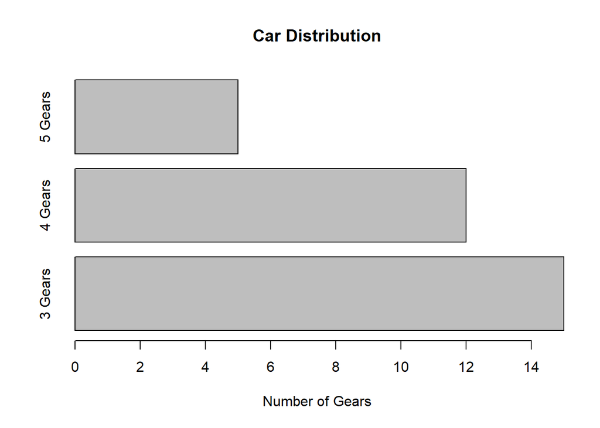

```r
counts <- table(mtcars$gear)
barplot(counts, main="Car Distribution", xlab="Number of Gears", horiz=TRUE,
        names.arg=c("3 Gears", "4 Gears", "5 Gears"))
```

만약 **벡터**가 아닌 **행렬** 자료가 입력된다면 어떻게 될까?

행렬은 여러개의 벡터가 합쳐진 형태이므로 x 축에 해당하는 값에 누적된 그림이 그려진다.

여러개의 자료가 한꺼번에 그림에 그려지므로 legend 를 사용하여 값들을 구분하고,

col 로 **색상을 지정**해주면 보기 좋은 그림이 그려진다.

```r
counts <- table(mtcars$vs, mtcars$gear)
counts
```

```
##
##      3  4  5
##   0 12  2  4
##   1  3 10  1
```

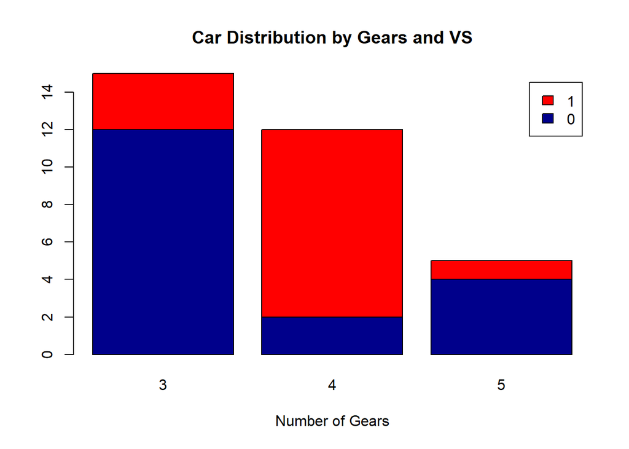

```r
barplot(counts, main="Car Distribution by Gears and VS",
        xlab="Number of Gears", col=c("darkblue","red"),
        legend = rownames(counts))
```

범례가 0과 1로 표현되어 맘에 들지 않거나, names.arg를 사용하기 싫다면

생성된 행렬의 행row.names()과 열colnames()에 이름을 줄 수 있다.

```r
counts <- table(mtcars$vs, mtcars$gear)
row.names(counts)=c("FS","RS")
colnames(counts)=c("3 Gears", "4 Gears", "5 Gears")
counts
```

```
##
##      3 Gears 4 Gears 5 Gears
##   FS      12       2       4
##   RS       3      10       1
```

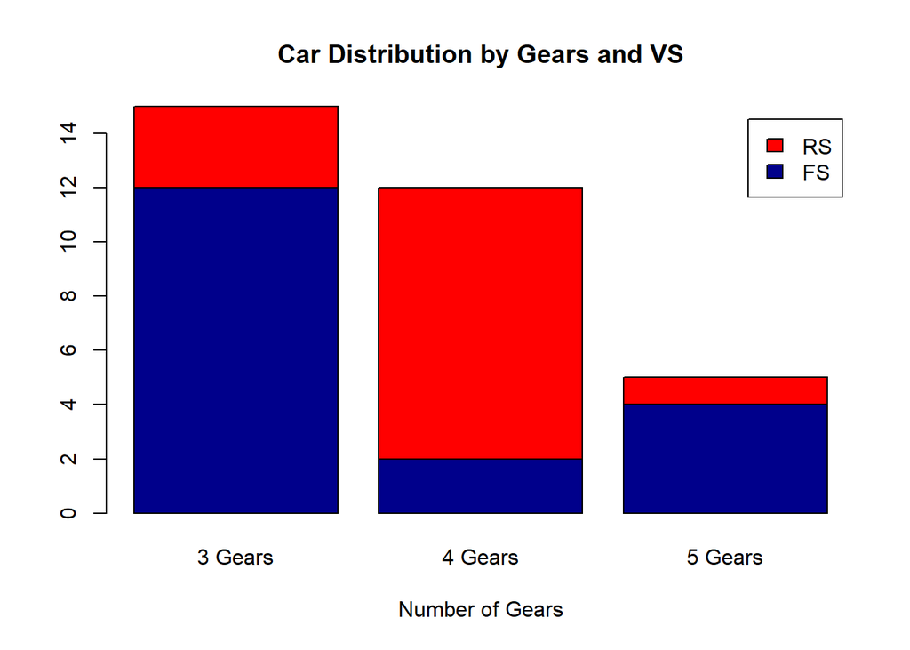

```r
barplot(counts, main="Car Distribution by Gears and VS",
        xlab="Number of Gears", col=c("darkblue","red"),
        legend = rownames(counts))
```

누적된 막대도표가 아니라 **옆으로 생성된 막대**가 보고 싶다면 beside parameter를 주면 된다.

물론, legend에 들어가는 값을 c()를 이용하여 **직접 입력**해도 된다.

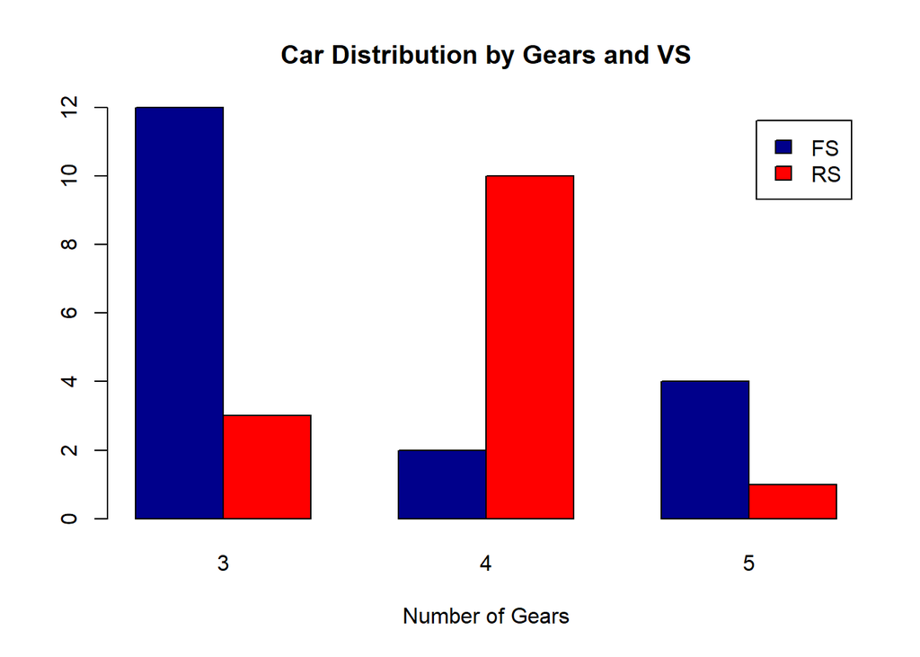

```r
counts <- table(mtcars$vs, mtcars$gear)
barplot(counts, main="Car Distribution by Gears and VS",
        xlab="Number of Gears", col=c("darkblue","red"),
        legend = c("FS","RS"), beside=TRUE)
```

기본적으로 수평의 막대도표의 이름은 **수직**으로 표현된다. 이를 **수평**으로 만들싶다면 par(las=2)를 사용하자.

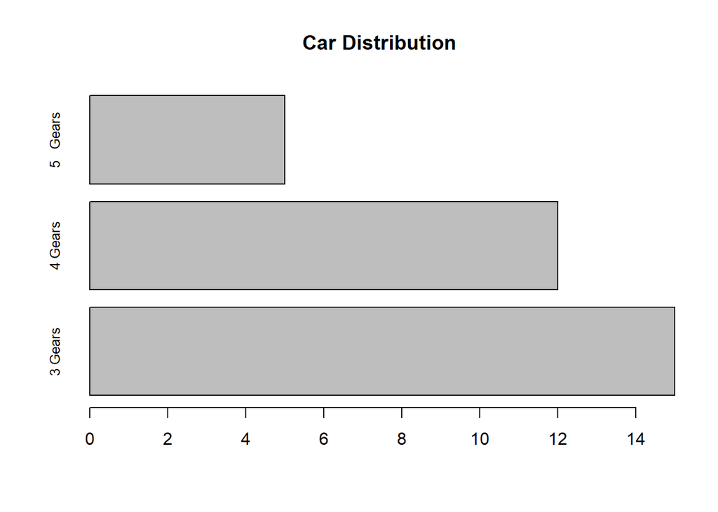

```r
counts <- table(mtcars$gear)
barplot(counts, main="Car Distribution", horiz=TRUE, names.arg=c("3 Gears", "4 Gears", "5   Gears"), cex.names=0.8)
```

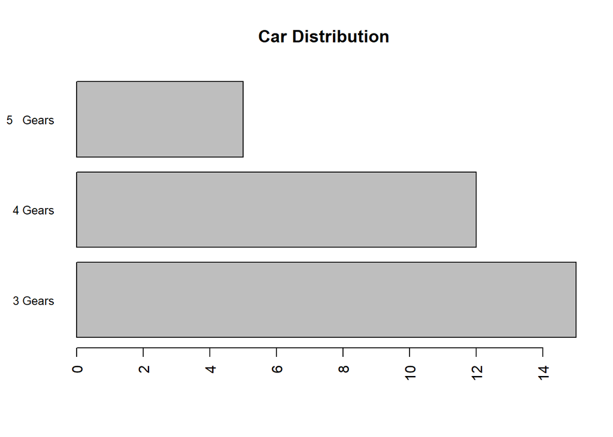

```r
par(las=2)
barplot(counts, main="Car Distribution", horiz=TRUE, names.arg=c("3 Gears", "4 Gears", "5   Gears"), cex.names=0.8)
```

여기까지는 숫자로 구성된 **벡터**와 **행렬**를 막대도표로 그리는 방법이다.

이제 barplot의 상세 사용법에 대해 알아보자.

아래는 2018 서울 구별 아파트 평균가격이다.

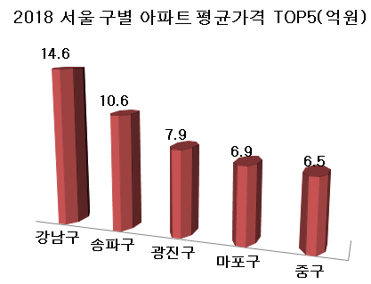

위 자료를 사용하여 막대도표를 그려보자.

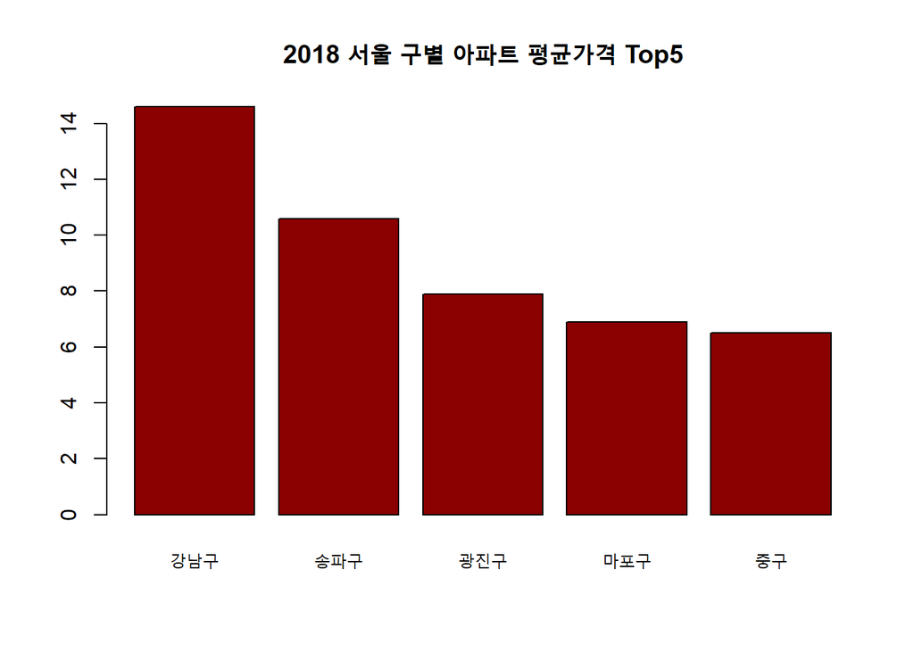

```r
apt <- c(14.6,10.6,7.9,6.9,6.5)
barplot(apt, names.arg = c("강남구","송파구","광진구","마포구","중구"),
        main="2018 서울 구별 아파트 평균가격 Top5", col="darkred")
```

그림과 비슷하지만 숫자가 그림에 표현되지 않아 가독성이 떨어진다.

이제 text 함수를 이용하여 숫자를 같이 출력하자.

**여기서 주의해야할 부분은 barplot을 저장하여 다시 사용**해야 원하는 위치에 숫자가 들어간다.

추가로 ylim를 통해 **숫자가 들어갈 여유공간**을 주자.

```r
apt <- c(14.6,10.6,7.9,6.9,6.5)
barp<-barplot(apt, names.arg = c("강남구","송파구","광진구","마포구","중구"),
        main="2018 서울 구별 아파트 평균가격 Top5", col="darkred", ylim=c(0,16))
barp
```

```
##      [,1]
## [1,]  0.7
## [2,]  1.9
## [3,]  3.1
## [4,]  4.3
## [5,]  5.5
```

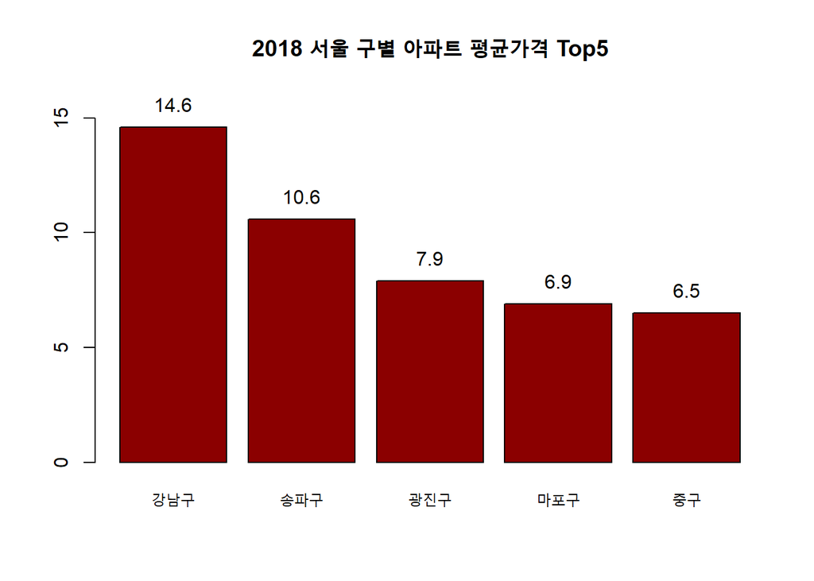

```r
text(barp, apt+1, labels=apt)
```

width는 **폭**이란 뜻이므로 width를 사용하면 barplot을 조금 더 과장해서 그릴 수 있다.

```r
apt <- c(14.6,10.6,7.9,6.9,6.5)
barp<-barplot(apt, names.arg = c("강남구","송파구","광진구","마포구","중구"),
        main="2018 서울 구별 아파트 평균가격 Top5", col="darkred", ylim=c(0,16),
        width=apt)
barp
```

```
##       [,1]
## [1,]  9.16
## [2,] 23.62
## [3,] 34.73
## [4,] 43.99
## [5,] 52.55
```

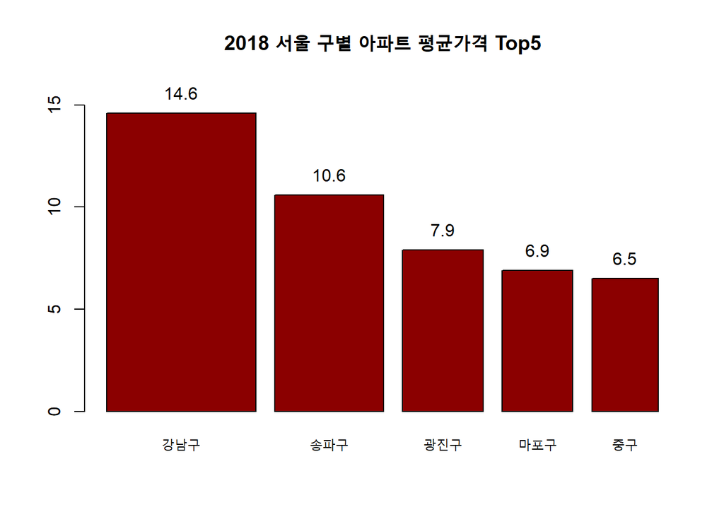

```r
text(barp, apt+1, labels=apt)
```

space는 막대와 막대 사이의 **거리**를 조정해준다.

```r
apt <- c(14.6,10.6,7.9,6.9,6.5)
barp<-barplot(apt, names.arg = c("강남구","송파구","광진구","마포구","중구"),
        main="2018 서울 구별 아파트 평균가격 Top5", col="darkred", ylim=c(0,16),
        width=apt, space=2)
barp
```

```
##        [,1]
## [1,]  25.90
## [2,]  57.10
## [3,]  84.95
## [4,] 110.95
## [5,] 136.25
```

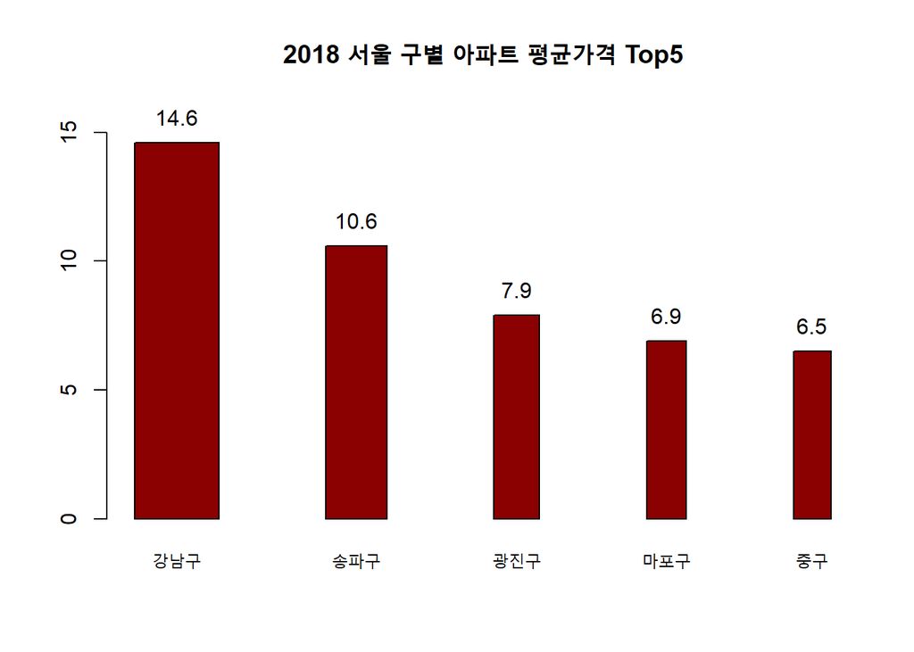

```r
text(barp, apt+1, labels=apt)
```

space는 행렬자료의 막대도표를 그릴 때, 아주 효과적이다.

```r
counts <- table(mtcars$vs, mtcars$gear)
counts
```

```
##
##      3  4  5
##   0 12  2  4
##   1  3 10  1
```

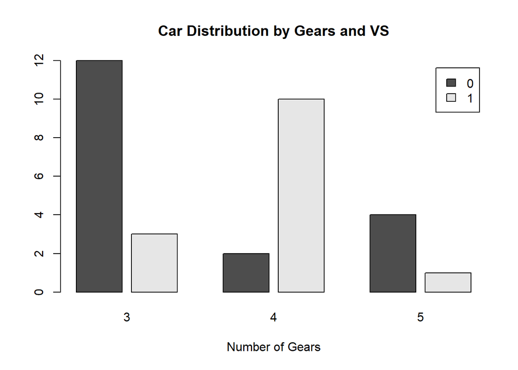

```r
barplot(counts, main="Car Distribution by Gears and VS",
        xlab="Number of Gears", beside=TRUE,
        legend = rownames(counts), space = c(0.2, 1))
```

density는 **밀도**를 의미하고 이 모수가 사용되면 사선을 통해 음영이 표현된다.

angle=135를 추가하면 사선의 **각도** 조정할 수 있다.

```r
apt <- c(14.6,10.6,7.9,6.9,6.5)
barp<-barplot(apt, names.arg = c("강남구","송파구","광진구","마포구","중구"),
        main="2018 서울 구별 아파트 평균가격 Top5", col="darkred", ylim=c(0,16),
        width=apt, density=5)
barp
```

```
##       [,1]
## [1,]  9.16
## [2,] 23.62
## [3,] 34.73
## [4,] 43.99
## [5,] 52.55
```

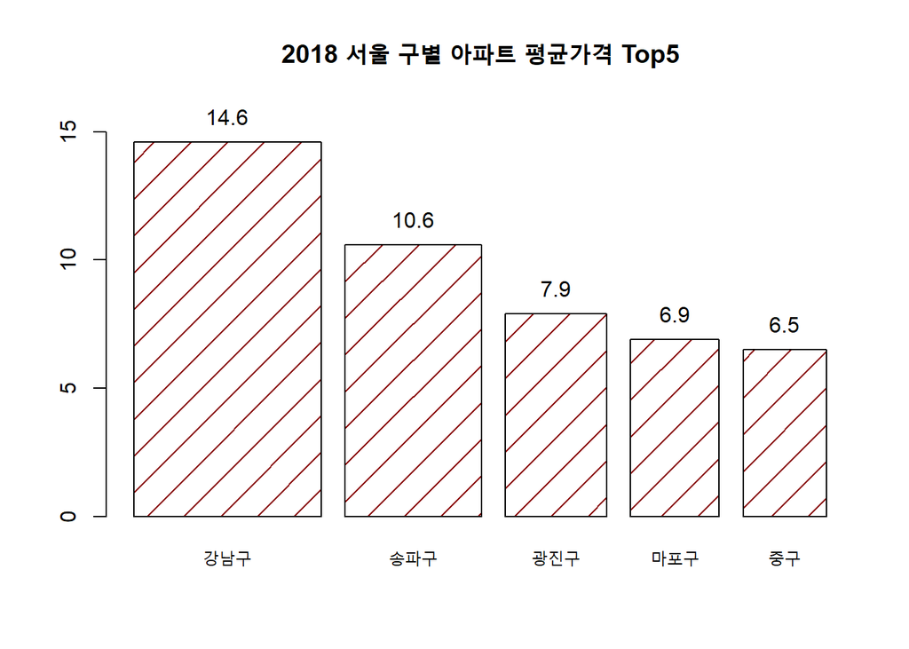

```r
text(barp, apt+1, labels=apt)
```

색상을 주면 훨씬 효율적으로 전달할 수 있다.

border 를 사용해서 막대 주변색도 지정할 있다.

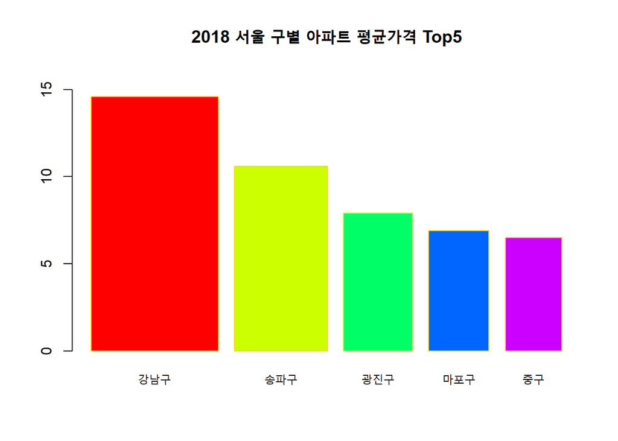

```r
apt <- c(14.6,10.6,7.9,6.9,6.5)
barplot(apt, names.arg = c("강남구","송파구","광진구","마포구","중구"),
        main="2018 서울 구별 아파트 평균가격 Top5", ylim=c(0,16),
        width=apt, col=rainbow(length(apt)), border="gold")
```

axes는 **축**을 의미하고 이 parameter를 FALSE로 설정하면 축이 표현되지 않는다.

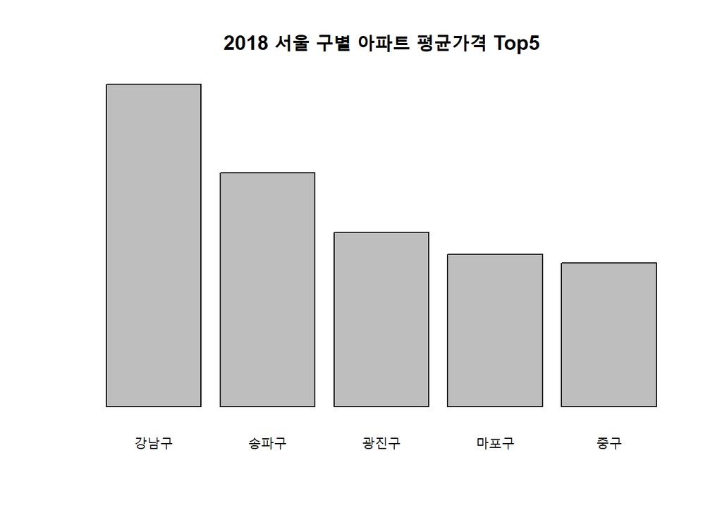

```r
apt <- c(14.6,10.6,7.9,6.9,6.5)
barplot(apt, names.arg = c("강남구","송파구","광진구","마포구","중구"),
        main="2018 서울 구별 아파트 평균가격 Top5", axes=FALSE)
```

기본적으로 *cex*는 **문자나 모양의 크기**를 지정하는데 사용된다.

따라서 cex.axis를 하용하면 축의 label를 크게 표현 할 수 있다.

아래 사이트를 참고하면 cex.lab, cex.main, cex.sub 의 parameter가 무엇인지 짐작할 수 있다.

- http://rfunction.com/archives/2154

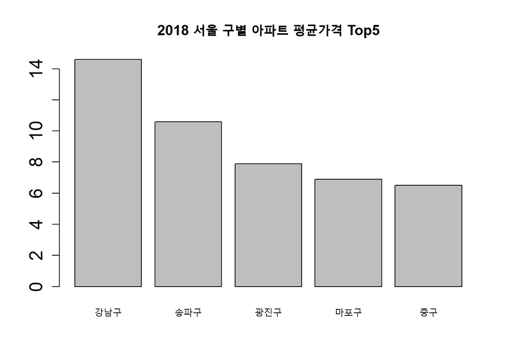

```r
apt <- c(14.6,10.6,7.9,6.9,6.5)
barplot(apt, names.arg = c("강남구","송파구","광진구","마포구","중구"),
        main="2018 서울 구별 아파트 평균가격 Top5", cex.axis=1.5)
```

여기까지 막대도표의 다양한 사용방법대해 배웠다. ***

**아래 그림은 흥미롭게도 가격이 올라간 지역와 떨어진 지역이 모두 있다. 이것도 barplot으로 표현될까?**

[figure not shown]

2018 서울 구별 아파트 가격을 음수처리하면 밑으로 그려지므로 크게 문제될 건 없다.

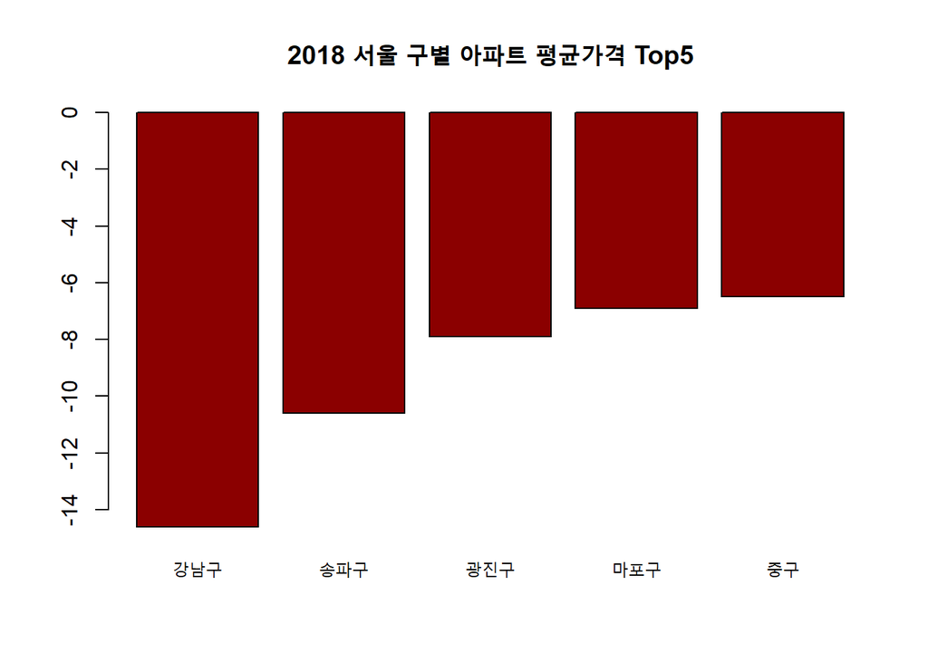

```r
apt <- c(14.6,10.6,7.9,6.9,6.5)
barplot(-apt, names.arg = c("강남구","송파구","광진구","마포구","중구"),
        main="2018 서울 구별 아파트 평균가격 Top5", col="darkred")
```

## 2019년 지역별 아파트 전세 재계약비용 그래프를 직접 입력하여 그려보세요.